# Identify Customer Segments

In this project, I will apply unsupervised learning techniques to identify segments of the population that form the core customer base for a mail-order sales company in Germany. These segments can then be used to direct marketing campaigns towards audiences that will have the highest expected rate of returns. The data was provided by Udacity's partners at Bertelsmann Arvato Analytics, and represents a real-life data science task.

```python
# Import all libraries
import numpy as np
import pandas as pd
import matplotlib.pyplot as plt
import seaborn as sns
%matplotlib inline

from sklearn.preprocessing import StandardScaler
from sklearn.decomposition import PCA
from sklearn.cluster import KMeans
```

### Step 0: Load the Data

Each row of the demographics files represents a single person, but also includes information outside of individuals, including information about their household, building, and neighborhood. I will use this information to cluster the general population into groups with similar demographic properties. Then, I will see how the people in the customers dataset fit into those created clusters. The hope here is that certain clusters are over-represented in the customers data, as compared to the general population; those over-represented clusters will be assumed to be part of the core userbase. This information can then be used for further applications, such as targeting for a marketing campaign.

To start off with, I will load in the demographics data for the general population into a pandas DataFrame, and do the same for the feature attributes summary.

```python
# Load in the general demographics data.
azdias = pd.read_csv('Udacity_AZDIAS_Subset.csv', sep=';')

# Load in the feature summary file.
feat_info = pd.read_csv('AZDIAS_Feature_Summary.csv', sep=';')
```

```python
# Check the structure of the data
print(azdias.shape)
azdias.head()
```

```
(891221, 85)
```

|  | AGER_TYP | ALTERSKATEGORIE_GROB | ANREDE_KZ | CJT_GESAMTTYP | FINANZ_MINIMALIST | FINANZ_SPARER | FINANZ_VORSORGER | FINANZ_ANLEGER | FINANZ_UNAUFFAELLIGER | FINANZ_HAUSBAUER | ... | PLZ8_ANTG1 | PLZ8_ANTG2 | PLZ8_ANTG3 | PLZ8_ANTG4 | PLZ8_BAUMAX | PLZ8_HHZ | PLZ8_GBZ | ARBEIT | ORTSGR_KLS9 | RELAT_AB |
| --- | --- | --- | --- | --- | --- | --- | --- | --- | --- | --- | --- | --- | --- | --- | --- | --- | --- | --- | --- | --- | --- |
| 0 | -1 | 2 | 1 | 2.0 | 3 | 4 | 3 | 5 | 5 | 3 | ... | NaN | NaN | NaN | NaN | NaN | NaN | NaN | NaN | NaN | NaN |
| 1 | -1 | 1 | 2 | 5.0 | 1 | 5 | 2 | 5 | 4 | 5 | ... | 2.0 | 3.0 | 2.0 | 1.0 | 1.0 | 5.0 | 4.0 | 3.0 | 5.0 | 4.0 |
| 2 | -1 | 3 | 2 | 3.0 | 1 | 4 | 1 | 2 | 3 | 5 | ... | 3.0 | 3.0 | 1.0 | 0.0 | 1.0 | 4.0 | 4.0 | 3.0 | 5.0 | 2.0 |
| 3 | 2 | 4 | 2 | 2.0 | 4 | 2 | 5 | 2 | 1 | 2 | ... | 2.0 | 2.0 | 2.0 | 0.0 | 1.0 | 3.0 | 4.0 | 2.0 | 3.0 | 3.0 |
| 4 | -1 | 3 | 1 | 5.0 | 4 | 3 | 4 | 1 | 3 | 2 | ... | 2.0 | 4.0 | 2.0 | 1.0 | 2.0 | 3.0 | 3.0 | 4.0 | 6.0 | 5.0 |

5 rows × 85 columns

```python
print(feat_info.shape)
feat_info.head()
```

```
(85, 4)
```

|  | attribute | information_level | type | missing_or_unknown |
| --- | --- | --- | --- | --- |
| 0 | AGER_TYP | person | categorical | [-1,0] |
| 1 | ALTERSKATEGORIE_GROB | person | ordinal | [-1,0,9] |
| 2 | ANREDE_KZ | person | categorical | [-1,0] |
| 3 | CJT_GESAMTTYP | person | categorical | [0] |
| 4 | FINANZ_MINIMALIST | person | ordinal | [-1] |

## Step 1: Preprocessing

### Step 1.1: Assess Missing Data

The feature summary file contains a summary of properties for each demographics data column. I will use this file to make cleaning decisions during this stage of the project. First of all, I will assess the demographics data in terms of missing data.

#### Step 1.1.1: Convert Missing Value Codes to NaNs

The fourth column of the feature attributes summary (loaded in above as `feat_info`) documents the codes from the data dictionary that indicate missing or unknown data. While the file encodes this as a list (e.g. `[-1,0]`), this will get read in as a string object. I will convert data that matches a 'missing' or 'unknown' value code into a numpy NaN value. I will see how much data takes on a 'missing' or 'unknown' code, and how much data is naturally missing, as a point of interest.

```python
# Identify missing or unknown code in feat_info
feat_info['missing_or_unknown'].value_counts()
```

```
[-1]        26
[-1,9]      17
[-1,0]      16
[0]         12
[]          10
[-1,0,9]     1
[-1,XX]      1
[-1,X]       1
[XX]         1
Name: missing_or_unknown, dtype: int64
```

```python
# Check if column variables in azdias are the same as attributes in feat_info
list(azdias.columns) == list(feat_info['attribute'])
```

```
True
```

I noticed that the "missing" or "unknown" code in dataframe `feat_info` are strings while the data in dataframe `azdias` are mostly floats or integers. Therefore I need to convert the code to a list of strings. Then I will use the code to replace the missing or unknown values in `azdias` with "null".

```python
# Convert missing or unknown code (str) in feat_info to list
# Use str.strip() to remove "[" and "]" and use str.split() to separate the content
feat_info['missing_or_unknown'] = feat_info['missing_or_unknown'].str.strip('[]').str.split(',')
```

```python
# Iterate through rows in feat_info and convert list of str to list of float
# Skip lists containing "X", "XX" and ""
for i in range(feat_info.shape[0]):
    lookup = ['X', 'XX', '']
    if any(e in lookup for e in feat_info['missing_or_unknown'][i]):
        pass
    else:
        feat_info['missing_or_unknown'][i] = [float(x) for x in feat_info['missing_or_unknown'][i]]
```

```python
# Replace missing or unknown values in azdias with null
for i, col in enumerate(list(azdias.columns)):
    azdias[col] = azdias[col].replace(feat_info['missing_or_unknown'][i], np.nan)

azdias.head()
```

|  | AGER_TYP | ALTERSKATEGORIE_GROB | ANREDE_KZ | CJT_GESAMTTYP | FINANZ_MINIMALIST | FINANZ_SPARER | FINANZ_VORSORGER | FINANZ_ANLEGER | FINANZ_UNAUFFAELLIGER | FINANZ_HAUSBAUER | ... | PLZ8_ANTG1 | PLZ8_ANTG2 | PLZ8_ANTG3 | PLZ8_ANTG4 | PLZ8_BAUMAX | PLZ8_HHZ | PLZ8_GBZ | ARBEIT | ORTSGR_KLS9 | RELAT_AB |
| --- | --- | --- | --- | --- | --- | --- | --- | --- | --- | --- | --- | --- | --- | --- | --- | --- | --- | --- | --- | --- | --- |
| 0 | NaN | 2.0 | 1 | 2.0 | 3 | 4 | 3 | 5 | 5 | 3 | ... | NaN | NaN | NaN | NaN | NaN | NaN | NaN | NaN | NaN | NaN |
| 1 | NaN | 1.0 | 2 | 5.0 | 1 | 5 | 2 | 5 | 4 | 5 | ... | 2.0 | 3.0 | 2.0 | 1.0 | 1.0 | 5.0 | 4.0 | 3.0 | 5.0 | 4.0 |
| 2 | NaN | 3.0 | 2 | 3.0 | 1 | 4 | 1 | 2 | 3 | 5 | ... | 3.0 | 3.0 | 1.0 | 0.0 | 1.0 | 4.0 | 4.0 | 3.0 | 5.0 | 2.0 |
| 3 | 2.0 | 4.0 | 2 | 2.0 | 4 | 2 | 5 | 2 | 1 | 2 | ... | 2.0 | 2.0 | 2.0 | 0.0 | 1.0 | 3.0 | 4.0 | 2.0 | 3.0 | 3.0 |
| 4 | NaN | 3.0 | 1 | 5.0 | 4 | 3 | 4 | 1 | 3 | 2 | ... | 2.0 | 4.0 | 2.0 | 1.0 | 2.0 | 3.0 | 3.0 | 4.0 | 6.0 | 5.0 |

5 rows × 85 columns

#### Step 1.1.2: Assess Missing Data in Each Column

There are a few columns that are outliers in terms of the proportion of values that are missing. I will use matplotlib's hist() to visualize the distribution of missing value counts to find these columns. While some of these columns might have justifications for keeping or re-encoding the data, for this project I will just remove them from the dataframe.

```python
# Check missing data in each column of azdias
azdias.isnull().sum()
```

```
AGER_TYP                 685843
ALTERSKATEGORIE_GROB       2881
ANREDE_KZ                     0
CJT_GESAMTTYP              4854
FINANZ_MINIMALIST             0
FINANZ_SPARER                 0
FINANZ_VORSORGER              0
FINANZ_ANLEGER                0
FINANZ_UNAUFFAELLIGER         0
FINANZ_HAUSBAUER              0
FINANZTYP                     0
GEBURTSJAHR              392318
GFK_URLAUBERTYP            4854
GREEN_AVANTGARDE              0
HEALTH_TYP               111196
LP_LEBENSPHASE_FEIN       97632
LP_LEBENSPHASE_GROB       94572
LP_FAMILIE_FEIN           77792
LP_FAMILIE_GROB           77792
LP_STATUS_FEIN             4854
LP_STATUS_GROB             4854
NATIONALITAET_KZ         108315
PRAEGENDE_JUGENDJAHRE    108164
RETOURTYP_BK_S             4854
SEMIO_SOZ                     0
SEMIO_FAM                     0
SEMIO_REL                     0
SEMIO_MAT                     0
SEMIO_VERT                    0
SEMIO_LUST                    0
                          ...
OST_WEST_KZ               93148
WOHNLAGE                  93148
CAMEO_DEUG_2015           99352
CAMEO_DEU_2015            99352
CAMEO_INTL_2015           99352
KBA05_ANTG1              133324
KBA05_ANTG2              133324
KBA05_ANTG3              133324
KBA05_ANTG4              133324
KBA05_BAUMAX             476524
KBA05_GBZ                133324
BALLRAUM                  93740
EWDICHTE                  93740
INNENSTADT                93740
GEBAEUDETYP_RASTER        93155
KKK                      158064
MOBI_REGIO               133324
ONLINE_AFFINITAET          4854
REGIOTYP                 158064
KBA13_ANZAHL_PKW         105800
PLZ8_ANTG1               116515
PLZ8_ANTG2               116515
PLZ8_ANTG3               116515
PLZ8_ANTG4               116515
PLZ8_BAUMAX              116515
PLZ8_HHZ                 116515
PLZ8_GBZ                 116515
ARBEIT                    97375
ORTSGR_KLS9               97274
RELAT_AB                  97375
Length: 85, dtype: int64
```

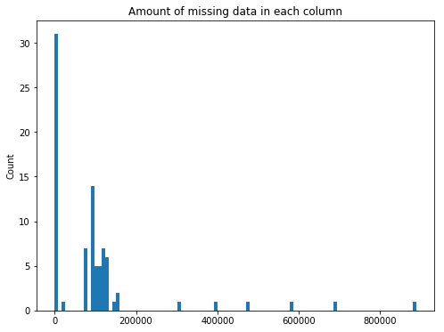

```python
# Plot the distribution of missing values in columns
plt.figure(figsize=(8, 6))
plt.hist(azdias.isnull().sum(), bins=100)
plt.title('Amount of missing data in each column')
plt.ylabel('Count');
```

```python
# Creat a new column in feat_info to store the amount of missing data in each column
feat_info['missing'] = azdias.isnull().sum().tolist()

# Find outliers that have more than 200,000 missing values
outliers = list(feat_info[feat_info['missing'] > 200000]['attribute'])
outliers
```

```
['AGER_TYP',
 'GEBURTSJAHR',
 'TITEL_KZ',
 'ALTER_HH',
 'KK_KUNDENTYP',
 'KBA05_BAUMAX']
```

```python
# Remove the outliers from azdias
azdias = azdias.drop(outliers, axis=1)

# Remove the outliers from feat_info
feat_info = feat_info[~feat_info['attribute'].isin(outliers)]
```

#### Step 1.1.3: Assess Missing Data in Each Row

Now, I will perform a similar assessment for the rows of the dataset. I will divide the data into two subsets: one for data points that are above some threshold for missing values, and a second subset for points below that threshold.

In order to know what to do with the outlier rows, I will see if the distribution of data values on columns that are not missing data (or are missing very little data) are similar or different between the two groups. I will select five of these columns and compare the distribution of values.

- I will use seaborn's countplot() to create a bar chart of code frequencies and matplotlib's subplot() to put bar charts for the two subplots side by side.
- To reduce repeated code, I will write a function that performs this comparison, taking as one of its arguments a column to be compared.

If the distributions of non-missing features look similar between the data with many missing values and the data with few or no missing values, then I could argue that simply dropping those points from the analysis won't present a major issue. On the other hand, if the data with many missing values looks very different from the data with few or no missing values, then I should make a note on those data as special. I will revisit these data later on. **But for now, I will continue the analysis using just the subset of the data with few or no missing values.**

```python
# Check missing data in each row of azdias
azdias.isnull().sum(axis=1)
```

```
0         43
1          0
2          0
3          7
4          0
5          0
6          0
7          0
8          0
9          0
10         0
11        47
12         6
13         8
14        47
```

[output cut: 47 more lines]

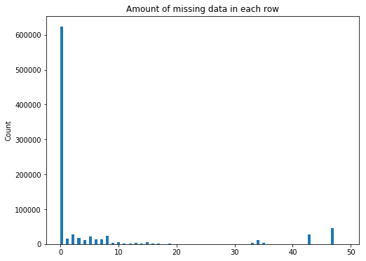

```python
# Plot the distribution of missing values in rows
plt.figure(figsize=(8, 6))
plt.hist(azdias.isnull().sum(axis=1), bins=100)
plt.title('Amount of missing data in each row')
plt.ylabel('Count');
```

```python
# Creat a new column in azdias to store the amount of missing data in each row
azdias['missing'] = azdias.isnull().sum(axis=1).tolist()

# Divide the data into azdias_most (>20 missing values) and azdias_few (<=20 missing values)
azdias_most = azdias[azdias['missing'] > 20]
azdias_few = azdias[azdias['missing'] <= 20]
```

```python
# Define a function to compare the distribution of columns between the two subsets
def compare_distribution(df1, df2, column):
    """
    Compare value distribution of column between df1 and df2.
    """
    base_color = sns.color_palette()[0]

    fig, ax = plt.subplots(1, 2, figsize=(8, 4))

    sns.countplot(df1[column], ax=ax[0], color=base_color)
    ax[0].set_title('azdias_most')

    sns.countplot(df2[column], ax=ax[1], color=base_color)
    ax[1].set_title('azdias_few')

    plt.subplots_adjust(wspace=0.6)
    plt.show();
```

```
Value Distribution of ANREDE_KZ:
```

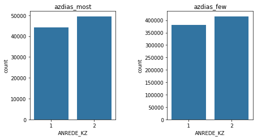

```
Value Distribution of FINANZ_MINIMALIST:
```

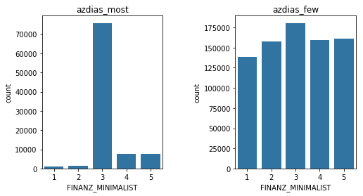

```
Value Distribution of FINANZ_SPARER:
```

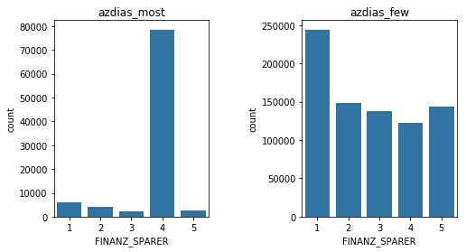

```
Value Distribution of FINANZ_VORSORGER:
```

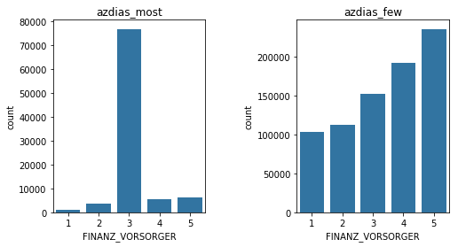

```
Value Distribution of FINANZ_ANLEGER:
```

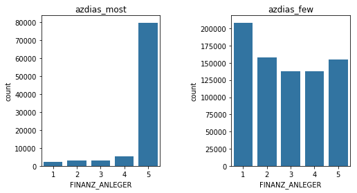

```python
# Find five columns with no missing data
columns = feat_info[feat_info['missing'] == 0]['attribute'][:5].tolist()

# Use compare_distribution function to compare data distribution
for column in columns:
    print(f'Value Distribution of {column}:')
    compare_distribution(azdias_most, azdias_few, column)
```

### Step 1.2: Select and Re-Encode Features

Checking for missing data isn't the only way in which I can prepare a dataset for analysis. Since the unsupervised learning techniques to be used will only work on data that is encoded numerically, I will make a few encoding changes or additional assumptions to be able to make progress. In addition, while almost all of the values in the dataset are encoded using numbers, not all of them represent numeric values.

- For numeric and interval data, these features can be kept without changes.
- Most of the variables in the dataset are ordinal in nature. While ordinal values may technically be non-linear in spacing, I will make an assumption that the ordinal variables can be treated as being interval in nature and will keep them without any changes.
- Special handling may be necessary for the remaining two variable types: categorical, and mixed.

In the first two parts of this sub-step, I will perform an investigation of the categorical and mixed-type features and decide whether I should keep, drop, or re-encode each. Then, in the last part, I will create a new dataframe with only the selected and engineered columns.

```python
# Check # of features in each data type
feat_info['type'].value_counts()
```

```
ordinal        49
categorical    18
mixed           6
numeric         6
Name: type, dtype: int64
```

#### Step 1.2.1: Re-Encode Categorical Features

For categorical data, I will ordinarily encode the levels as dummy variables. Depending on the number of categories, I will perform one of the following:

- For binary (two-level) categorical variables that take numeric values, I can keep them without changes.
- There is one binary variable that takes on non-numeric values. For this one, I will re-encode the values as numbers or create a dummy variable.
- For multi-level categorical variables, I will encode the values using multiple dummy variables, or just drop them from the analysis.

```python
# Impute data before re-encoding
fill_mode = lambda col: col.fillna(col.mode()[0])
azdias_few = azdias_few.apply(fill_mode)

sum(azdias_few.isnull().sum())
```

```
0
```

```python
# Assess categorical variables: binary and multi-level
# Store categorical variables to a list
cat_vars = feat_info[feat_info['type'] == 'categorical']['attribute'].tolist()

# Iterate through the list to find binary and multi-level categorical variables and append them to lists
binary_vars = []
multi_vars = []

for var in cat_vars:
    if len(azdias_few[var].value_counts()) == 2:
        binary_vars.append(var)
    else:
        multi_vars.append(var)

print(f'Binary categorical variables: \n{binary_vars}\n')
print(f'Multi-level categorical variables: \n{multi_vars}')
```

```
Binary categorical variables:
['ANREDE_KZ', 'GREEN_AVANTGARDE', 'SOHO_KZ', 'VERS_TYP', 'OST_WEST_KZ']

Multi-level categorical variables:
['CJT_GESAMTTYP', 'FINANZTYP', 'GFK_URLAUBERTYP', 'LP_FAMILIE_FEIN', 'LP_FAMILIE_GROB', 'LP_STATUS_FEIN', 'LP_STATUS_GROB', 'NATIONALITAET_KZ', 'SHOPPER_TYP', 'ZABEOTYP', 'GEBAEUDETYP', 'CAMEO_DEUG_2015', 'CAMEO_DEU_2015']
```

```python
# Find the binary categorical variable that takes non-numeric values
binary_object = azdias_few[binary_vars].select_dtypes(include='object')
binary_object.head()
```

|  | OST_WEST_KZ |
| --- | --- |
| 1 | W |
| 2 | W |
| 3 | W |
| 4 | W |
| 5 | W |

```python
azdias_few['OST_WEST_KZ'].value_counts()
```

```
W    628987
O    168439
Name: OST_WEST_KZ, dtype: int64
```

```python
# Create new code for OST_WEST_KZ {W: 0, O:1}
azdias_few['OST_WEST_KZ'] = azdias_few['OST_WEST_KZ'].replace({'W':0, 'O':1})
azdias_few['OST_WEST_KZ'].head()
```

```
1    0
2    0
3    0
4    0
5    0
Name: OST_WEST_KZ, dtype: int64
```

```python
# Find the multi-level categorical variable that takes non-numeric values
multi_object = azdias_few[multi_vars].select_dtypes(include='object')
multi_object.head()
```

|  | CAMEO_DEUG_2015 | CAMEO_DEU_2015 |
| --- | --- | --- |
| 1 | 8 | 8A |
| 2 | 4 | 4C |
| 3 | 2 | 2A |
| 4 | 6 | 6B |
| 5 | 8 | 8C |

```python
azdias_few['CAMEO_DEUG_2015'].value_counts()
```

```
8    140411
9    108152
6    105840
4    103842
3     86666
2     83174
7     77904
5     55249
1     36188
Name: CAMEO_DEUG_2015, dtype: int64
```

```python
azdias_few['CAMEO_DEU_2015'].value_counts()
```

```
6B    62656
8A    52430
4C    47779
2D    35059
3C    34753
7A    34389
3D    34285
8B    33427
4A    33137
8C    30983
9D    28592
9B    27665
9C    24986
7B    24493
9A    20538
2C    19412
8D    17568
6E    16105
2B    15469
5D    14937
6C    14817
2A    13234
5A    12177
1D    11908
1A    10842
3A    10483
5B    10346
5C     9928
7C     9062
4B     9039
4D     8567
3B     7145
6A     6802
9E     6371
6D     6071
6F     5392
7D     5331
4E     5320
1E     5058
7E     4629
1C     4312
5F     4281
1B     4068
5E     3580
Name: CAMEO_DEU_2015, dtype: int64
```

```python
# Drop column CAMEO_DEU_2015
azdias_few = azdias_few.drop('CAMEO_DEU_2015', axis=1)
```

```python
# Apply get_dummies() to CAMEO_DEUG_2015 and drop the orginal column
CAMEO_DEUG_2015 = pd.get_dummies(azdias_few['CAMEO_DEUG_2015'], prefix='CAMEO_DEUG_2015')
azdias_few = pd.concat([azdias_few, CAMEO_DEUG_2015], axis=1)
azdias_few = azdias_few.drop('CAMEO_DEUG_2015', axis=1)

azdias_few.shape[1]
```

```
87
```

#### Discussion 1.2.1: Re-Encode Categorical Features

I imputed the data before re-encoding so I didn't have to deal with null. I decided to **drop CAMEO_DEU_2015** because it contains too many levels of data. Then I created dummy variables for binary categorical variable, **OST_WEST_KZ**, and multi-level categorical variable, **CAMEO_DEUG_2015**.

#### Step 1.2.2: Engineer Mixed-Type Features

There are a handful of features that are marked as "mixed" in the feature summary that require special treatment in order to be included in the analysis.

- "PRAEGENDE_JUGENDJAHRE" combines information on three dimensions: generation by decade, movement (mainstream vs. avantgarde), and nation (east vs. west). While there aren't enough levels to disentangle east from west, I will create two new variables to capture the other two dimensions: an interval-type variable for decade, and a binary variable for movement.
- "CAMEO_INTL_2015" combines information on two axes: wealth and life stage. I will break up the two-digit codes by their 'tens'-place and 'ones'-place digits into two new ordinal variables.

```python
# Investigate "PRAEGENDE_JUGENDJAHRE" and engineer two new variables.
print(azdias_few['PRAEGENDE_JUGENDJAHRE'].dtypes)
azdias_few['PRAEGENDE_JUGENDJAHRE'].unique()
```

```
float64
```

```
array([ 14.,  15.,   8.,   3.,  10.,  11.,   5.,   9.,   6.,   4.,   2.,
         1.,  12.,  13.,   7.])
```

```python
# Create new code for PRAEGENDE_JUGENDJAHRE
# for generation: {1: 40s, 2: 50s, 3: 60s, 4: 70s, 5: 80s, 6: 90s}
# for movement: {0: Mainstream, 1: Avantgarde}
to_replace = {1: [1, 0],
              2: [1, 1],
              3: [2, 0],
              4: [2, 1],
              5: [3, 0],
              6: [3, 1],
              7: [3, 1],
              8: [4, 0],
              9: [4, 1],
              10: [5, 0],
              11: [5, 1],
              12: [5, 0],
              13: [5, 1],
              14: [6, 0],
              15: [6, 1]}

# Replace the orginal values with the new values
azdias_few['PRAEGENDE_JUGENDJAHRE'] = azdias_few['PRAEGENDE_JUGENDJAHRE'].map(to_replace)

# Create a new column PRAEGENDE_JUGENDJAHRE_GEN to store generation
azdias_few['PRAEGENDE_JUGENDJAHRE_GEN'] = azdias_few['PRAEGENDE_JUGENDJAHRE'].apply(lambda x: x[0])

# Create a new column PRAEGENDE_JUGENDJAHRE_MOV to store movement
azdias_few['PRAEGENDE_JUGENDJAHRE_MOVE'] = azdias_few['PRAEGENDE_JUGENDJAHRE'].apply(lambda x: x[1])

# Remove the original column
azdias_few = azdias_few.drop('PRAEGENDE_JUGENDJAHRE', axis=1)

azdias_few[['PRAEGENDE_JUGENDJAHRE_GEN', 'PRAEGENDE_JUGENDJAHRE_MOVE']].head()
```

|  | PRAEGENDE_JUGENDJAHRE_GEN | PRAEGENDE_JUGENDJAHRE_MOVE |
| --- | --- | --- |
| 1 | 6 | 0 |
| 2 | 6 | 1 |
| 3 | 4 | 0 |
| 4 | 4 | 0 |
| 5 | 2 | 0 |

```python
# Investigate "CAMEO_INTL_2015" and engineer two new variables.
print(azdias_few['CAMEO_INTL_2015'].dtypes)
azdias_few['CAMEO_INTL_2015'].unique()
```

```
object
```

```
array(['51', '24', '12', '43', '54', '22', '14', '13', '15', '33', '41',
       '34', '55', '25', '23', '31', '52', '35', '45', '44', '32'], dtype=object)
```

```python
# Create a new column CAMEO_INTL_2015_WEALTH to store wealth
azdias_few['CAMEO_INTL_2015_WEALTH'] = azdias_few['CAMEO_INTL_2015'].apply(lambda x: x[0])

# Create a new column CAMEO_INTL_2015_LIFE to store life stage
azdias_few['CAMEO_INTL_2015_LIFE'] = azdias_few['CAMEO_INTL_2015'].apply(lambda x: x[1])

# Remove the original column
azdias_few = azdias_few.drop('CAMEO_INTL_2015', axis=1)

azdias_few[['CAMEO_INTL_2015_WEALTH', 'CAMEO_INTL_2015_LIFE']].head()
```

|  | CAMEO_INTL_2015_WEALTH | CAMEO_INTL_2015_LIFE |
| --- | --- | --- |
| 1 | 5 | 1 |
| 2 | 2 | 4 |
| 3 | 1 | 2 |
| 4 | 4 | 3 |
| 5 | 5 | 4 |

```python
feat_info[feat_info['type'] == 'mixed']['attribute']
```

```
15      LP_LEBENSPHASE_FEIN
16      LP_LEBENSPHASE_GROB
22    PRAEGENDE_JUGENDJAHRE
56                 WOHNLAGE
59          CAMEO_INTL_2015
79              PLZ8_BAUMAX
Name: attribute, dtype: object
```

```python
# Drop other columns with mixted types of data
azdias_few = azdias_few.drop(['LP_LEBENSPHASE_FEIN', 'LP_LEBENSPHASE_GROB', 'WOHNLAGE', 'PLZ8_BAUMAX'], axis=1)
```

#### Discussion 1.2.2: Engineer Mixed-Type Features

I created new columns to store generation and movement information of PRAEGENDE_JUGENDJAHRE and wealth and life stage information of CAMEO_INTL_2015. Then I decided to **drop columns LP_LEBENSPHASE_FEIN, LP_LEBENSPHASE_GROB, WOHNLAGE and PLZ8_BAUMAX** because the former two contain repeated information as other columns and the latter two have mixed values.

#### Step 1.2.3: Complete Feature Selection

In order to finish this step up, I will make sure that the data frame now only has the columns that I want to keep. To summarize, the dataframe should consist of the following:

- All numeric, interval, and ordinal type columns from the original dataset.
- Binary categorical features (all numerically-encoded).
- Engineered features from other multi-level categorical features and mixed features.

I will make sure that for any new columns that I have engineered, I have excluded the original columns from the final dataset. Otherwise, their values will interfere with the analysis later on the project.

```python
# Remove column "missing"
azdias_few = azdias_few.drop('missing', axis=1)
azdias_few.head()
```

|  | ALTERSKATEGORIE_GROB | ANREDE_KZ | CJT_GESAMTTYP | FINANZ_MINIMALIST | FINANZ_SPARER | FINANZ_VORSORGER | FINANZ_ANLEGER | FINANZ_UNAUFFAELLIGER | FINANZ_HAUSBAUER | FINANZTYP | ... | CAMEO_DEUG_2015_4 | CAMEO_DEUG_2015_5 | CAMEO_DEUG_2015_6 | CAMEO_DEUG_2015_7 | CAMEO_DEUG_2015_8 | CAMEO_DEUG_2015_9 | PRAEGENDE_JUGENDJAHRE_GEN | PRAEGENDE_JUGENDJAHRE_MOVE | CAMEO_INTL_2015_WEALTH | CAMEO_INTL_2015_LIFE |
| --- | --- | --- | --- | --- | --- | --- | --- | --- | --- | --- | --- | --- | --- | --- | --- | --- | --- | --- | --- | --- | --- |
| 1 | 1.0 | 2 | 5.0 | 1 | 5 | 2 | 5 | 4 | 5 | 1 | ... | 0 | 0 | 0 | 0 | 1 | 0 | 6 | 0 | 5 | 1 |
| 2 | 3.0 | 2 | 3.0 | 1 | 4 | 1 | 2 | 3 | 5 | 1 | ... | 1 | 0 | 0 | 0 | 0 | 0 | 6 | 1 | 2 | 4 |
| 3 | 4.0 | 2 | 2.0 | 4 | 2 | 5 | 2 | 1 | 2 | 6 | ... | 0 | 0 | 0 | 0 | 0 | 0 | 4 | 0 | 1 | 2 |
| 4 | 3.0 | 1 | 5.0 | 4 | 3 | 4 | 1 | 3 | 2 | 5 | ... | 0 | 0 | 1 | 0 | 0 | 0 | 4 | 0 | 4 | 3 |
| 5 | 1.0 | 2 | 2.0 | 3 | 1 | 5 | 2 | 2 | 5 | 2 | ... | 0 | 0 | 0 | 0 | 1 | 0 | 2 | 0 | 5 | 4 |

5 rows × 84 columns

### Step 1.3: Create a Cleaning Function

```python
def clean_data(df, feat_info):
    """
    Perform feature trimming, re-encoding, and engineering for demographics data

    INPUT:
        df - demographics datagrame
        feat_info - feature summary dataframe

    OUTPUT:
        Trimmed and cleaned demographics datagrame
    """
    # Put in code here to execute all main cleaning steps:

    # Check if column variables in df are the same as attributes in feat_info
    result = list(df.columns) == list(feat_info['attribute'])

    if result:
        # Convert missing value codes into null
        print('Converting missing code......')
        feat_info['missing_or_unknown'] = feat_info['missing_or_unknown'].str.strip('[]').str.split(',')

        for i in range(feat_info.shape[0]):
            lookup = ['X', 'XX', '']
            if any(e in lookup for e in feat_info['missing_or_unknown'][i]):
                pass
            else:
                feat_info['missing_or_unknown'][i] = [float(x) for x in feat_info['missing_or_unknown'][i]]

        for i, col in enumerate(list(df.columns)):
            df[col] = df[col].replace(feat_info['missing_or_unknown'][i], np.nan)

        # Remove outliers that have more than 200,000 missing values in each column
        print('Removing outliers......')
        feat_info['missing'] = df.isnull().sum().tolist()
        outliers = list(feat_info[feat_info['missing'] > 200000]['attribute'])
        df = df.drop(outliers, axis=1)
        feat_info = feat_info[~feat_info['attribute'].isin(outliers)]

        # Remove outliers that have more than 20 missing values in each row
        df['missing'] = df.isnull().sum(axis=1).tolist()
        df = df[df['missing'] <= 20]

        # Fill null with mode
        print('Imputing data......')
        fill_mode = lambda col: col.fillna(col.mode()[0])
        df = df.apply(fill_mode)

        # Assess and re-encode categorical variables
        print('Re-encoding categorical variables......')
        # Re-encode binary categorical variables
        df['OST_WEST_KZ'] = df['OST_WEST_KZ'].replace({'W':0, 'O':1})

        # Re-encode multi-level categorical variables
        df = df.drop('CAMEO_DEU_2015', axis=1)

        CAMEO_DEUG_2015 = pd.get_dummies(df['CAMEO_DEUG_2015'], prefix='CAMEO_DEUG_2015')
        df = pd.concat([df, CAMEO_DEUG_2015], axis=1)
        df = df.drop('CAMEO_DEUG_2015', axis=1)

        # Engineer Mixed-Type Features
        # PRAEGENDE_JUGENDJAHRE
        print('Engineering variable "PRAEGENDE_JUGENDJAHRE"......')
        to_replace = {1: [1, 1],
                      2: [1, 2],
                      3: [2, 1],
                      4: [2, 2],
                      5: [3, 1],
                      6: [3, 2],
                      7: [3, 2],
                      8: [4, 1],
                      9: [4, 2],
                      10: [5, 1],
                      11: [5, 2],
                      12: [5, 1],
                      13: [5, 2],
                      14: [6, 1],
                      15: [6, 2]}
        df['PRAEGENDE_JUGENDJAHRE'] = df['PRAEGENDE_JUGENDJAHRE'].map(to_replace)
        df['PRAEGENDE_JUGENDJAHRE_GEN'] = df['PRAEGENDE_JUGENDJAHRE'].apply(lambda x: x[0])
        df['PRAEGENDE_JUGENDJAHRE_MOVE'] = df['PRAEGENDE_JUGENDJAHRE'].apply(lambda x: x[1])
        df = df.drop('PRAEGENDE_JUGENDJAHRE', axis=1)

        # CAMEO_INTL_2015
        print('Engineering variable "CAMEO_INTL_2015"......')
        df['CAMEO_INTL_2015_WEALTH'] = df['CAMEO_INTL_2015'].apply(lambda x: x[0])
        df['CAMEO_INTL_2015_LIFE'] = df['CAMEO_INTL_2015'].apply(lambda x: x[1])
        df = df.drop('CAMEO_INTL_2015', axis=1)

        # Drop other columns with mixted types of data
        print('Dropping other mixed variables......')
        df = df.drop(['LP_LEBENSPHASE_FEIN', 'LP_LEBENSPHASE_GROB', 'WOHNLAGE', 'PLZ8_BAUMAX'], axis=1)

        # Drop variable missing
        df = df.drop('missing', axis=1)

    else:
        print('The column variables of the input dataframe are not consistent with the attributes of feat_info.')

    return df
```

## Step 2: Feature Transformation

### Step 2.1: Apply Feature Scaling

Before applying dimensionality reduction techniques to the data, I should perform feature scaling so that the principal component vectors are not influenced by the natural differences in scale for features. I will check the following:

- Sklearn requires that data doesn't have missing values in order for its estimators to work properly.
- For the actual scaling function, I will use StandardScaler that scales each feature to mean of 0 and standard deviation of 1.

```python
# Apply feature scaling to the general population demographics data
scaler = StandardScaler()
azdias_scaled = pd.DataFrame(scaler.fit_transform(azdias_few))
azdias_scaled.columns = azdias_few.columns
azdias_scaled.index = azdias_few.index

azdias_scaled.head()
```

|  | ALTERSKATEGORIE_GROB | ANREDE_KZ | CJT_GESAMTTYP | FINANZ_MINIMALIST | FINANZ_SPARER | FINANZ_VORSORGER | FINANZ_ANLEGER | FINANZ_UNAUFFAELLIGER | FINANZ_HAUSBAUER | FINANZTYP | ... | CAMEO_DEUG_2015_4 | CAMEO_DEUG_2015_5 | CAMEO_DEUG_2015_6 | CAMEO_DEUG_2015_7 | CAMEO_DEUG_2015_8 | CAMEO_DEUG_2015_9 | PRAEGENDE_JUGENDJAHRE_GEN | PRAEGENDE_JUGENDJAHRE_MOVE | CAMEO_INTL_2015_WEALTH | CAMEO_INTL_2015_LIFE |
| --- | --- | --- | --- | --- | --- | --- | --- | --- | --- | --- | --- | --- | --- | --- | --- | --- | --- | --- | --- | --- | --- |
| 1 | -1.766334 | 0.958071 | 0.974628 | -1.494609 | 1.538200 | -1.040726 | 1.466448 | 0.959677 | 1.338816 | -1.342572 | ... | -0.386934 | -0.27284 | -0.391203 | -0.329047 | 2.163152 | -0.396115 | 1.098531 | -0.530567 | 1.175734 | -1.249157 |
| 2 | 0.200589 | 0.958071 | -0.329598 | -1.494609 | 0.864824 | -1.766955 | -0.570799 | 0.244962 | 1.338816 | -1.342572 | ... | 2.584420 | -0.27284 | -0.391203 | -0.329047 | -0.462288 | -0.396115 | 1.098531 | 1.884775 | -0.869674 | 0.766845 |
| 3 | 1.184051 | 0.958071 | -0.981711 | 0.683150 | -0.481928 | 1.137960 | -0.570799 | -1.184467 | -0.792034 | 1.055872 | ... | -0.386934 | -0.27284 | -0.391203 | -0.329047 | -0.462288 | -0.396115 | -0.267356 | -0.530567 | -1.551476 | -0.577156 |
| 4 | 0.200589 | -1.043765 | 0.974628 | 0.683150 | 0.191448 | 0.411731 | -1.249881 | 0.244962 | -0.792034 | 0.576183 | ... | -0.386934 | -0.27284 | 2.556220 | -0.329047 | -0.462288 | -0.396115 | -0.267356 | -0.530567 | 0.493932 | 0.094845 |
| 5 | -1.766334 | 0.958071 | -0.981711 | -0.042770 | -1.155304 | 1.137960 | -0.570799 | -0.469752 | 1.338816 | -0.862883 | ... | -0.386934 | -0.27284 | -0.391203 | -0.329047 | 2.163152 | -0.396115 | -1.633243 | -0.530567 | 1.175734 | 0.766845 |

5 rows × 84 columns

### Discussion 2.1: Apply Feature Scaling

In step 1.2.1, I filled missing data with mode because mode is less affected by outliers. Then I used StandardScaler to standardize the data.

### Step 2.2: Perform Dimensionality Reduction

I will apply dimensionality reduction techniques on the scaled data.

- I will use sklearn's PCA to apply principal component analysis on the data, thus finding the vectors of maximal variance in the data. To start, I will not set any parameters (so all components are computed) or set a number of components that is at least half the number of features (so there's enough features to see the general trend in variability).
- I will check out the ratio of variance explained by each principal component as well as the cumulative variance explained using matplotlib's plot(). Based on the result, I will select a value for the number of transformed features I will retain for the clustering part of the project.

```python
# Apply PCA to the data
pca_84 = PCA(84)
azdias_pca_84 = pca_84.fit_transform(azdias_scaled)
```

```python
# Define a function to visualize the variance explained by each principal component
def scree_plot(pca):
    """
    Creates a scree plot associated with the principal components.
    """
    n_comps = len(pca.explained_variance_ratio_)
    index = np.arange(n_comps)
    values = pca.explained_variance_ratio_

    plt.figure(figsize=(10, 6))
    ax = plt.subplot(111)
    cum_values = np.cumsum(values)
    ax.bar(index, values)
    ax.plot(index, cum_values)
    for i in range(5):
        ax.annotate(r"%s%%" % ((str(values[i]*100)[:4])), (index[i]+0.2, values[i]), va="bottom", ha="center", fontsize=12)

    ax.xaxis.set_tick_params(width=0)
    ax.yaxis.set_tick_params(width=2, length=12)

    ax.set_xlabel("Principal Component")
    ax.set_ylabel("Variance Explained (%)")
    plt.title('Explained Variance Per Principal Component')
```

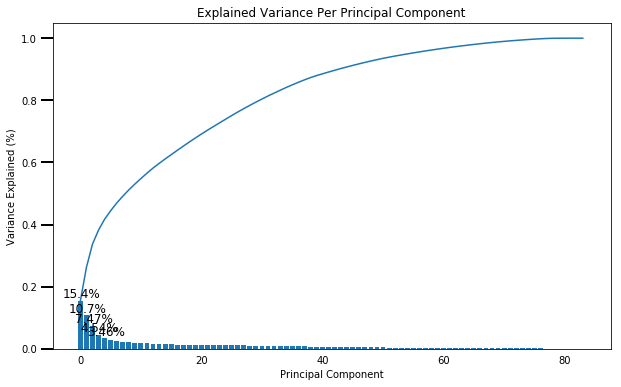

```python
scree_plot(pca_84)
```

```python
# Re-apply PCA to the data while selecting for number of components to retain
pca_20 = PCA(20)
azdias_pca_20 = pca_20.fit_transform(azdias_scaled)
```

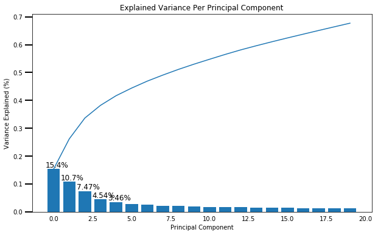

```python
scree_plot(pca_20)
```

```python
pca_20.explained_variance_ratio_.sum()
```

```
0.67733108762476235
```

### Discussion 2.2: Perform Dimensionality Reduction

Totally, there are 84 components. I decided to retain **20 principal components that explain 67.8% variance**.

### Step 2.3: Interpret Principal Components

With the transformed principal components, I will check out the weight of each variable on the first few components to see if they can be interpreted in some fashion.

Each principal component is a unit vector that points in the direction of highest variance (after accounting for the variance captured by earlier principal components). The further a weight is from zero, the more the principal component is in the direction of the corresponding feature. If two features have large weights of the same sign (both positive or both negative), then increases in one tend expect to be associated with increases in the other. To contrast, features with different signs can be expected to show a negative correlation: increases in one variable should result in decreases in the other.

- To investigate the features, I will map each weight to their corresponding feature name, then sort the features according to weight. The most interesting features for each principal component will then be those at the beginning and end of the sorted list.
- I will write a function that prints the sorted list of feature weights, for the *i*-th principal component. This will help facilitate the investigation and interpretation of feature associations from the first three principal components.

```python
# Create a dataframe to show each weight to their corresponding feature name
def pca_result(pca, df):
    """
    Create a dataframe df_comp to show weights to their corresponding features of each component/dimension.
    """
    dimensions = [f'Dimension {i}' for i in range(1, len(pca.components_) + 1)]

    df_comp = pd.DataFrame(np.round(pca.components_, 4))
    df_comp.columns = list(df.columns)
    df_comp.index = dimensions

    # Add variance ratio explained by each component/dimension
    variance_ratios = pca.explained_variance_ratio_.reshape(len(pca.components_), 1)
    df_variance = pd.DataFrame(np.round(variance_ratios, 4))
    df_variance.columns = ['Explained Variance']
    df_variance.index = dimensions

    df_comp = pd.concat([df_variance, df_comp], axis=1)

    return df_comp
```

```python
azdias_comp = pca_result(pca_20, azdias_scaled)
azdias_comp.head()
```

|  | Explained Variance | ALTERSKATEGORIE_GROB | ANREDE_KZ | CJT_GESAMTTYP | FINANZ_MINIMALIST | FINANZ_SPARER | FINANZ_VORSORGER | FINANZ_ANLEGER | FINANZ_UNAUFFAELLIGER | FINANZ_HAUSBAUER | ... | CAMEO_DEUG_2015_4 | CAMEO_DEUG_2015_5 | CAMEO_DEUG_2015_6 | CAMEO_DEUG_2015_7 | CAMEO_DEUG_2015_8 | CAMEO_DEUG_2015_9 | PRAEGENDE_JUGENDJAHRE_GEN | PRAEGENDE_JUGENDJAHRE_MOVE | CAMEO_INTL_2015_WEALTH | CAMEO_INTL_2015_LIFE |
| --- | --- | --- | --- | --- | --- | --- | --- | --- | --- | --- | --- | --- | --- | --- | --- | --- | --- | --- | --- | --- | --- |
| Dimension 1 | 0.1541 | -0.0940 | 0.0159 | 0.0394 | -0.2069 | 0.1241 | -0.0917 | 0.0591 | 0.0576 | 0.1615 | ... | -0.0779 | -0.0105 | 0.0034 | 0.0372 | 0.0967 | 0.1211 | 0.0848 | -0.1147 | 0.1976 | -0.1169 |
| Dimension 2 | 0.1079 | 0.2602 | 0.0776 | -0.1266 | 0.0823 | -0.2409 | 0.2330 | -0.2063 | -0.2302 | 0.1010 | ... | -0.0368 | -0.0058 | 0.0145 | 0.0120 | 0.0391 | 0.0217 | -0.2443 | -0.0114 | 0.0625 | 0.0088 |
| Dimension 3 | 0.0748 | 0.0616 | -0.3630 | -0.0354 | 0.1458 | -0.0918 | 0.0853 | -0.1750 | -0.0927 | -0.0420 | ... | -0.0273 | -0.0038 | 0.0002 | 0.0019 | 0.0211 | 0.0274 | -0.0967 | 0.0425 | 0.0363 | -0.0162 |
| Dimension 4 | 0.0454 | -0.0336 | 0.0389 | 0.0767 | 0.0480 | 0.0010 | -0.0208 | -0.0971 | 0.0497 | -0.0784 | ... | -0.0492 | 0.0262 | -0.0373 | -0.0182 | -0.0149 | -0.0036 | 0.0299 | 0.3273 | -0.0674 | 0.0258 |
| Dimension 5 | 0.0347 | 0.0555 | -0.0143 | 0.0410 | 0.0259 | -0.0142 | 0.0053 | 0.0771 | -0.0969 | -0.0138 | ... | 0.0145 | -0.0368 | 0.0063 | 0.0036 | 0.0542 | 0.0623 | -0.0011 | -0.1535 | 0.1124 | -0.0585 |

5 rows × 85 columns

```python
# Define a function to show a sorted list of feature weights
def sort_features(dim, df):
    """
    Return the sorted list of feature weights for the number of dimension/principal component.
    """
    return df.iloc[dim-1,:].sort_values()
```

```python
# Map weights for the first principal component to corresponding feature names and print the linked values,
# sorted by weight
sort_features(1, azdias_comp)[:5]
```

```
LP_STATUS_FEIN      -0.2225
LP_STATUS_GROB      -0.2217
MOBI_REGIO          -0.2069
FINANZ_MINIMALIST   -0.2069
PLZ8_ANTG1          -0.2018
Name: Dimension 1, dtype: float64
```

```python
sort_features(1, azdias_comp)[-5:]
```

```
ORTSGR_KLS9               0.1708
PLZ8_ANTG4                0.1932
CAMEO_INTL_2015_WEALTH    0.1976
HH_EINKOMMEN_SCORE        0.1995
PLZ8_ANTG3                0.2008
Name: Dimension 1, dtype: float64
```

```python
sort_features(2, azdias_comp)[-5:]
```

```
RETOURTYP_BK_S          0.1615
SEMIO_LUST              0.1808
SEMIO_ERL               0.2232
FINANZ_VORSORGER        0.2330
ALTERSKATEGORIE_GROB    0.2602
Name: Dimension 2, dtype: float64
```

```python
# Map weights for the third principal component to corresponding feature names and print the linked values,
# sorted by weight
sort_features(3, azdias_comp)[:5]
```

```
ANREDE_KZ    -0.3630
SEMIO_KAEM   -0.3317
SEMIO_DOM    -0.3081
SEMIO_KRIT   -0.2724
SEMIO_RAT    -0.2008
Name: Dimension 3, dtype: float64
```

```python
sort_features(3, azdias_comp)[-5:]
```

```
FINANZ_MINIMALIST    0.1458
SEMIO_KULT           0.2416
SEMIO_FAM            0.2546
SEMIO_SOZ            0.2602
SEMIO_VERT           0.3365
Name: Dimension 3, dtype: float64
```

### Discussion 2.3: Interpret Principal Components

**1st principal component**

The top positive features include number of 6-10 family houses, household net income and wealth type; the top negative features include social status and movement patterns. All these features indicate that the 1st principal component is about **high share of 6-10 family homes, low income and high movement**.

**2nd principal component**

The top positive features include personality type (dreamful, socially-minded and family-minded); the top negative features include gender and personality type (combative attitude, dominant-minded). The 3rd principal component is about **no dream, combative personality and male**.

## Step 3: Clustering

### Step 3.1: Apply Clustering to General Population

I have assessed and cleaned the demographics data, then scaled and transformed them. Now, it's time to see how the data clusters in the principal components space. In this substep, I will apply k-means clustering to the dataset and use the average within-cluster distances from each point to their assigned cluster's centroid to decide on a number of clusters to keep.

- I will use sklearn's KMeans to perform k-means clustering on the PCA-transformed data.
- Then, I will compute the average difference from each point to its assigned cluster's center.
- Perform the above two steps for a number of different cluster counts. I will then see how the average distance decreases with an increasing number of clusters. However, each additional cluster provides a smaller net benefit. I will use this fact to select a final number of clusters in which to group the data.
- Once I decide a final number of clusters to use, I will re-fit a KMeans instance to perform the clustering operation.

```python
# Over a number of different cluster counts...
# run k-means clustering on the data and...
# compute the average within-cluster distances.
kmeans_2 = KMeans(2)
kmodel_2 = kmeans_2.fit(azdias_pca_20)
kmodel_2.score(azdias_pca_20)
```

```
-37528192.496492468
```

```python
# Investigate the change in within-cluster distance across number of clusters
# Define a function to plot the result across number of clusters
def elbow_method(n_cluster, data):
    """
    Plot the kmeans scores of data across number of clusters.

    Input: n_cluster - number of clusters
           data
    """
    centers = list(range(1, n_cluster+1))
    scores = []
    for center in centers:
        kmeans = KMeans(center)
        model = kmeans.fit(data)
        score = np.absolute(model.score(data))
        scores.append(score)

    plt.plot(centers, scores, linestyle='--', marker='o', color='b')
    plt.xlabel('K')
    plt.ylabel('Score')
    plt.title('Score vs. Number of Clusters');
```

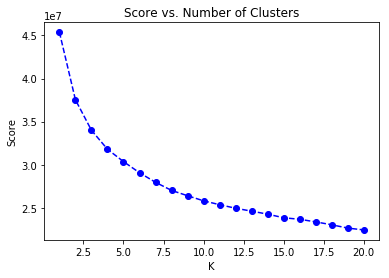

```python
elbow_method(20, azdias_pca_20)
```

```python
# Re-fit the k-means model with the selected number of clusters and obtain cluster predictions for
# the general population demographics data
kmeans_10 = KMeans(10)
kmodel_10 = kmeans_10.fit(azdias_pca_20)
azdias_clust = kmodel_10.predict(azdias_pca_20)
```

### Discussion 3.1: Apply Clustering to General Population

After applied the elbow method, I decided to choose **10 clusters** to segment the population because the average distance decrease after this number is getting smaller.